# FRED_Project_CCAenvfit

Nat Pombubpa

Updated on October 26, 2018

# This is a documentation for generating CCA plot with environmental fit

Note: environmental data are imported with metadata/mapping file. This approach use phyloseq object and plot_ordination.

### STEP1: Load all necessary packages for analysis

More information about Phyloseq can be found at the following link: [Phyloseq](https://joey711.github.io/phyloseq/) If you get error in this step, you probably need to install any packages which causes error.

```r
library(ape)
library(vegan)
library(plyr)
library(dplyr)
library(scales)
library(grid)
library(reshape2)
library(phyloseq)
library(magrittr)
library(ggplot2)
library(ggpubr)
library(data.table)
```

### STEP2: Import Mapping file (metadate file)

1.Check mapping file before import to R, R will automatically change sample name that starts with number or contain “-” in sample name. If you get error in this step, you should check sample name first.

2.First column of first row should not start with #, R will not read the first row that starts with ‘#’

3.You can choose which samples to include in analysis by indicating specific group in the column

4.This mapping file had been modified to remove special characters in environmental data

```r
meta = read.table("Jornada16S_mappingfileFAH.txt",
                  header=TRUE,row.names=1,
                  sep="\t",stringsAsFactors=FALSE)
```

### STEP3: Construct sample_data-class using imported metadata

```r
sampleData <- sample_data(meta)
```

### STEP4: Import OTU table

OTU table from Jornada 16S data is “Pietras16S.otu_table.fix.txt”.

```r
otus <- read.table("Pietras16S.otu_table.fix.txt",
                   header=T,sep="\t",row.names = 1)
otumat <- as(as.matrix(otus), "matrix")
OTU = otu_table(otumat, taxa_are_rows = TRUE)
```

### STEP5: Import taxonomy table

Taxonmy table generated from AMPtk need to be rearranged using following script.

“perl rdp_taxonmy2mat.pl<Input_taxonmy.txt>Output_taxonomy.txt”

rdp_taxonomy2mat.pl was created by Professor Jason E. Stajich

```r
taxmat <- read.table("Pietras16S.taxonomy.fix.txt",
                     header=T,sep="\t",row.names=1)
taxmat <- as(as.matrix(taxmat),"matrix")
TAX = tax_table(taxmat)
```

### STEP6: Import phylogenetic tree

Phylogenetic tree can also be include for furthur phylogenetic analysis. The tree was generated when we run AMPtk on Discovery and can be dowload using Rsync.

Rsync -ai yourusername[AT]discovery.nmsu.edu:/PATH_to_File PATH_to_Working_Directory

```r
treefile = "Pietras16S.tree.phy"
tree = read.tree(treefile)
```

### STEP7: Construct Phyloseq object

To construct phyloseq object, otu table, taxonomy table, and sampleData are required. Phylogenetic tree can be included, but it is not necessary for constructing phyloseq object. Construct Phyloseq object called “Physeq”

```r
physeq = phyloseq(OTU,TAX,sampleData,tree)
```

### STEP8: Check phyloseq object

This should indicate that your physeq is a “phyloseq-class experiment-level object”

```r
physeq
```

```
## phyloseq-class experiment-level object
## otu_table()   OTU Table:         [ 19279 taxa and 34 samples ]
## sample_data() Sample Data:       [ 34 samples by 25 sample variables ]
## tax_table()   Taxonomy Table:    [ 19279 taxa by 7 taxonomic ranks ]
## phy_tree()    Phylogenetic Tree: [ 19279 tips and 19278 internal nodes ]
```

### STEP9: Remove singletons

Remove any OTUs that present only one time.

```r
physeq.prune = prune_taxa(taxa_sums(physeq) > 1, physeq)
```

```r
physeq.prune
```

```
## phyloseq-class experiment-level object
## otu_table()   OTU Table:         [ 11292 taxa and 34 samples ]
## sample_data() Sample Data:       [ 34 samples by 25 sample variables ]
## tax_table()   Taxonomy Table:    [ 11292 taxa by 7 taxonomic ranks ]
## phy_tree()    Phylogenetic Tree: [ 11292 tips and 11291 internal nodes ]
```

### STEP10: Check read counts to check dataset

Check read counts: any samples that have very low reads should be removed. [Ref](http://evomics.org/wp-content/uploads/2016/01/phyloseq-Lab-01-Answers.html)

```r
readcount = data.table(as(sample_data(physeq.prune), "data.frame"),
                 TotalReads = sample_sums(physeq.prune),
                 keep.rownames = TRUE)
setnames(readcount, "rn", "SampleID")

#For plotting, use command below.
#SeqDepth = ggplot(readcount, aes(TotalReads)) + geom_histogram() + ggtitle("Sequencing Depth")
```

```r
readcount = readcount[order(readcount$TotalReads), c("SampleID", "TotalReads")]
```

```r
head(readcount)
```

```
##       SampleID TotalReads
## 1: N38.JOR.NPP      29454
## 2: N36.JOR.NPP      30823
## 3: N14.JOR.NPP      36644
## 4:  N1.JOR.NPP      36742
## 5: N22.JOR.NPP      37437
## 6: N10.JOR.NPP      39661
```

### STEP11:Rarefy OTUs to a minimum number of reads

Rarefy OTUs (remove any samples that has very low number of reads). In this case, no sample was remove because number of reads are over 20,000 however, sample.size was indicated to rarefy number reads to the smallest size (lowest number of reads).

```r
set.seed(711)
physeq.prune.rarefy = rarefy_even_depth(physeq.prune, sample.size = 29454, replace = FALSE, trimOTUs = TRUE)
```

```
## You set `rngseed` to FALSE. Make sure you've set & recorded
##  the random seed of your session for reproducibility.
## See `?set.seed`
```

```
## ...
```

```
## 373OTUs were removed because they are no longer
## present in any sample after random subsampling
```

```
## ...
```

```r
physeq.prune.rarefy
```

```
## phyloseq-class experiment-level object
## otu_table()   OTU Table:         [ 10919 taxa and 34 samples ]
## sample_data() Sample Data:       [ 34 samples by 25 sample variables ]
## tax_table()   Taxonomy Table:    [ 10919 taxa by 7 taxonomic ranks ]
## phy_tree()    Phylogenetic Tree: [ 10919 tips and 10918 internal nodes ]
```

### STEP12: Calculate ordinate and distance using CCA + PERMANOVA

```r
ps.dist = phyloseq::distance(physeq.prune.rarefy, "unifrac")
```

Using adonis funciton to run PERMANOVA on distance matrix generated from command above. The currently preferred analysis for evaluating differences among groups is PERMANOVA. This analysis partitions sums of squares using dissimilarities, evaluating differences in the centroids of groups in multivariate space. The vegan functions “adonis” is used to compute PERMANOVA in R.

```r
set.seed(1)
adonis(ps.dist ~EC+pH+Clay+Silt+Sand+Gravel
                                       +Sand_Fraction1to2mm+Sand_Fraction.5to1mm+Sand_Fraction.25to.5mm
                                       +Sand_Fraction.1to.25.mm+Sand_Fraction.05to.1mm+MSM_No_Cover.pct.
                                       +MSM_Total_Cover.pct.+MSM_Thick_Cover.pct.Thick.Average
                                       +MSM_Patchy_Cover.pct.+MSM_Thick_Patchy_Togther_Cover.pct., as(sample_data(physeq.prune.rarefy),"data.frame"))
```

```
##
## Call:
## adonis(formula = ps.dist ~ EC + pH + Clay + Silt + Sand + Gravel +      Sand_Fraction1to2mm + Sand_Fraction.5to1mm + Sand_Fraction.25to.5mm +      Sand_Fraction.1to.25.mm + Sand_Fraction.05to.1mm + MSM_No_Cover.pct. +      MSM_Total_Cover.pct. + MSM_Thick_Cover.pct.Thick.Average +      MSM_Patchy…
##
## Permutation: free
## Number of permutations: 999
##
## Terms added sequentially (first to last)
##
##                                     Df SumsOfSqs MeanSqs F.Model      R2
## EC                                   1   0.26676 0.26676  3.9523 0.08521
## pH                                   1   0.23128 0.23128  3.4266 0.07388
## Clay                                 1   0.31799 0.31799  4.7114 0.10158
## Silt                                 1   0.17300 0.17300  2.5632 0.05526
## Gravel                               1   0.14356 0.14356  2.1270 0.04586
## Sand_Fraction1to2mm                  1   0.07818 0.07818  1.1584 0.02498
## Sand_Fraction.5to1mm                 1   0.08828 0.08828  1.3080 0.02820
## Sand_Fraction.25to.5mm               1   0.09413 0.09413  1.3947 0.03007
## Sand_Fraction.1to.25.mm              1   0.09145 0.09145  1.3549 0.02921
## Sand_Fraction.05to.1mm               1   0.05868 0.05868  0.8695 0.01875
## MSM_No_Cover.pct.                    1   0.08202 0.08202  1.2153 0.02620
## MSM_Total_Cover.pct.                 1   0.08930 0.08930  1.3231 0.02853
## MSM_Thick_Cover.pct.Thick.Average    1   0.08446 0.08446  1.2514 0.02698
## MSM_Patchy_Cover.pct.                1   0.06171 0.06171  0.9144 0.01971
## MSM_Thick_Patchy_Togther_Cover.pct.  1   0.05473 0.05473  0.8109 0.01748
## Residuals                           18   1.21489 0.06749         0.38809
## Total                               33   3.13044                 1.00000
##                                     Pr(>F)
## EC                                   0.001 ***
## pH                                   0.001 ***
## Clay                                 0.001 ***
## Silt                                 0.002 **
## Gravel                               0.007 **
## Sand_Fraction1to2mm                  0.222
## Sand_Fraction.5to1mm                 0.111
## Sand_Fraction.25to.5mm               0.083 .
## Sand_Fraction.1to.25.mm              0.107
## Sand_Fraction.05to.1mm               0.627
## MSM_No_Cover.pct.                    0.179
## MSM_Total_Cover.pct.                 0.122
## MSM_Thick_Cover.pct.Thick.Average    0.129
## MSM_Patchy_Cover.pct.                0.532
## MSM_Thick_Patchy_Togther_Cover.pct.  0.781
## Residuals
## Total
## ---
## Signif. codes:  0 '***' 0.001 '**' 0.01 '*' 0.05 '.' 0.1 ' ' 1
```

```r
physeq.prune.rarefy.ps.cca <- ordinate(physeq.prune.rarefy, "CCA",
                                       formula = ~EC+pH+Clay+Silt+Sand+Gravel
                                       +Sand_Fraction.25to.5mm)
```

### STEP13: Plot ordination

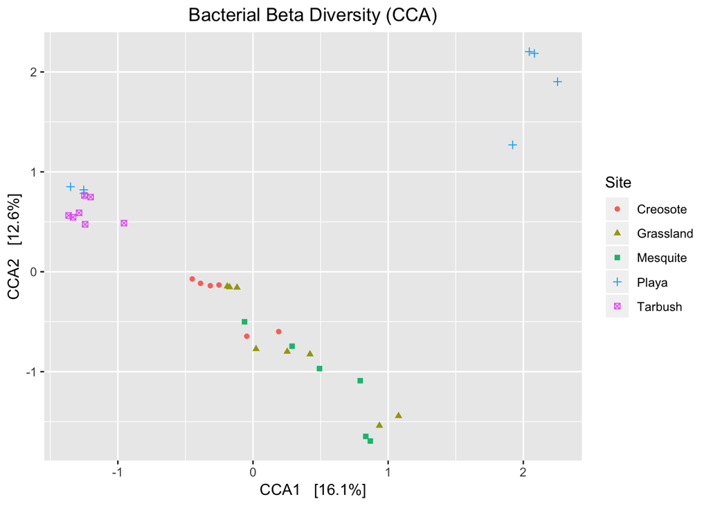

```r
plot_ordination(physeq.prune.rarefy, physeq.prune.rarefy.ps.cca, type = "samples",
                color = "Site", shape = "Site") + ggtitle("Bacterial Beta Diversity (CCA)") + theme(plot.title = element_text(hjust = 0.5))
```

add ordination plot to a variable “pcca”

```r
pcca = plot_ordination(physeq.prune.rarefy, physeq.prune.rarefy.ps.cca, type = "samples",
                       color = "Site", shape = "Site")
```

### STEP14: Get environmental distance from CCA to arrows

```r
arrowdist <- vegan::scores(physeq.prune.rarefy.ps.cca, display = c("bp"))
```

Check data for arrow distance, you should see your environmental factor with distances (CCA1 and CCA2)

```r
head(arrowdist)
```

```
##                               CCA1       CCA2
## EC                      0.14005796  0.7346617
## pH                     -0.22211248  0.7790603
## Clay                    0.49418831  0.8661153
## Silt                    0.11768795  0.9288830
## Gravel                  0.07320184 -0.3650643
## Sand_Fraction.25to.5mm  0.40064674 -0.5012960
```

### STEP15: Add arrow distance to data frame

```r
arrowdf <- data.frame(labels = rownames(arrowdist), arrowdist)
```

Check data frame for arrow distance

```r
head(arrowdf)
```

```
##                                        labels        CCA1       CCA2
## EC                                         EC  0.14005796  0.7346617
## pH                                         pH -0.22211248  0.7790603
## Clay                                     Clay  0.49418831  0.8661153
## Silt                                     Silt  0.11768795  0.9288830
## Gravel                                 Gravel  0.07320184 -0.3650643
## Sand_Fraction.25to.5mm Sand_Fraction.25to.5mm  0.40064674 -0.5012960
```

### STEP16: Define arrow starting point and labels

```r
arrow_map = aes(xend = CCA1, yend = CCA2, x = 0, y = 0, shape = NULL, color = NULL, label = labels)
label_map = aes(x = 1.1 * CCA1, y = 1.1 * CCA2, shape = NULL, color = NULL, label = labels)
```

### STEP17: Add environemntal arrow data to plot

```r
arrowhead = arrow(length = unit(0.05, "npc"))
pcca.envfit = pcca + geom_segment(arrow_map, size = 0.8, data = arrowdf, color = "gray",
    arrow = arrowhead) + geom_text(label_map, size = 3, data = arrowdf) +
  ggtitle("Bacterial Beta Diversity (CCA)") + theme(plot.title = element_text(hjust = 0.5))
```

### STEP18: CCA plot with environmental fit

Now, the CCA plot should inculde environmental arrows.

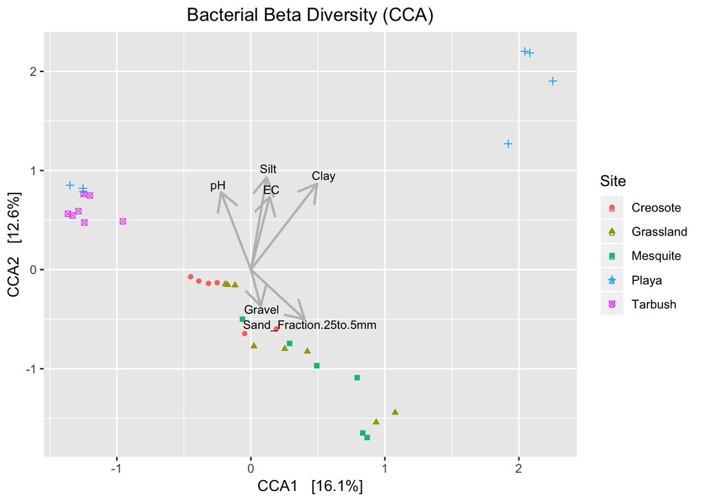

```r
pcca.envfit
```

### STEP19: Alpha diversity

Check metadata header to select variables to test for alpha diversity differences. In this case, we will focus on Site and DisturbanceType

```r
head(sample_data(physeq.prune.rarefy))
```

```
##             BarcodeSequence
## N1.JOR.NPP     AGATCGTGCCTA
## N10.JOR.NPP    AGCGCGGCGAAT
## N11.JOR.NPP    TTGAACAAGCCA
## N12.JOR.NPP    TTAATGGATCGG
## N14.JOR.NPP    GTCACTCCGAAC
## N18.JOR.NPP    CGTTCTGGTGGT
##                                                                    LinkerPrimerSequence
## N1.JOR.NPP  AATGATACGGCGACCACCGAGATCTACACGCTAGATCGTGCCTATATGGTAATTGTGTGYCAGCMGCCGCGGTAA
## N10.JOR.NPP AATGATACGGCGACCACCGAGATCTACACGCTAGCGCGGCGAATTATGGTAATTGTGTGYCAGCMGCCGCGGTAA
## N11.JOR.NPP AATGATACGGCGACCACCGAGATCTACACGCTTTGAACAAGCCATATGGTAATTGTGTGYCAGCMGCCGCGGTAA
## N12.JOR.NPP AATGATACGGCGACCACCGAGATCTACACGCTTTAATGGATCGGTATGGTAATTGTGTGYCAGCMGCCGCGGTAA
## N14.JOR.NPP AATGATACGGCGACCACCGAGATCTACACGCTGTCACTCCGAACTATGGTAATTGTGTGYCAGCMGCCGCGGTAA
## N18.JOR.NPP AATGATACGGCGACCACCGAGATCTACACGCTCGTTCTGGTGGTTATGGTAATTGTGTGYCAGCMGCCGCGGTAA
##             PrimerPlate PrimerWells Owner DisturbanceType      Site
## N1.JOR.NPP      Plate 2          C7  Fred               U   Tarbush
## N10.JOR.NPP     Plate 2         D11  Fred               U  Creosote
## N11.JOR.NPP     Plate 2         E12  Fred               D Grassland
## N12.JOR.NPP     Plate 2          E8  Fred               D  Mesquite
## N14.JOR.NPP     Plate 2          E5  Fred               U  Mesquite
## N18.JOR.NPP     Plate 2          E6  Fred               D  Mesquite
##                  SiteN           Description   pH    EC  Clay  Silt Sand
## N1.JOR.NPP   4_Tarbush T- Taylor Undisturbed 7.14 0.598 14.58 34.62 50.8
## N10.JOR.NPP 3_Creosote   C- Grav Undisturbed 7.17 0.774 10.45 23.75 65.8
## N11.JOR.NPP    2_Grass      G-Basn Disturebd 7.07 0.569 13.36 13.04 73.6
## N12.JOR.NPP 1_Mesquite     M- Well Disturbed 6.86 0.439  8.22  7.18 84.6
## N14.JOR.NPP 1_Mesquite   M- Rabb Undisturbed 6.44 0.549  7.32  3.98 88.7
## N18.JOR.NPP 1_Mesquite     M- Rabb Disturbed 6.45 0.316  7.34  7.96 84.7
##                 Gravel Sand_Fraction1to2mm Sand_Fraction.5to1mm
## N1.JOR.NPP   1.6417377              3.4884               6.0046
## N10.JOR.NPP 33.9518246              8.9137              13.3993
## N11.JOR.NPP  2.2403434              5.9788              20.0429
## N12.JOR.NPP  3.6908071              0.7118               6.9484
## N14.JOR.NPP  0.6824246              0.7080               7.7332
## N18.JOR.NPP  1.0670523              1.2027               7.5692
##             Sand_Fraction.25to.5mm Sand_Fraction.1to.25.mm
## N1.JOR.NPP                 18.5665                 45.6157
## N10.JOR.NPP                15.0760                 32.1582
## N11.JOR.NPP                26.5010                 32.6060
## N12.JOR.NPP                33.0245                 44.3905
```

[output cut: 8 more lines]

```
## N18.JOR.NPP                  10.23             84.26                15.74
##             MSM_Thick_Cover.pct.Thick.Average MSM_Patchy_Cover.pct.
## N1.JOR.NPP                               7.41                 91.67
## N10.JOR.NPP                              0.00                 46.30
## N11.JOR.NPP                              0.93                 51.85
## N12.JOR.NPP                              0.93                 19.44
## N14.JOR.NPP                              0.00                 21.30
## N18.JOR.NPP                              0.00                 15.74
##             MSM_Thick_Patchy_Togther_Cover.pct.
## N1.JOR.NPP                                 0.93
## N10.JOR.NPP                                0.00
## N11.JOR.NPP                                0.00
## N12.JOR.NPP                                0.00
## N14.JOR.NPP                                0.00
## N18.JOR.NPP                                0.00
```

#### Plot Alpha diversity for Site (5 vegetation types)

Anova can be added direclty to alpha diversity plot using “stat_compare_means”

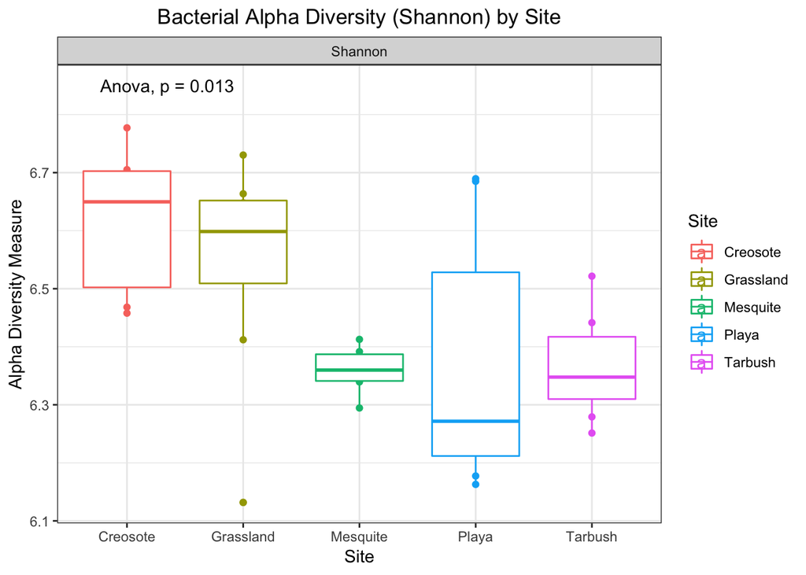

```r
physeq.prune.rarefy.plot.richness = plot_richness(physeq.prune.rarefy, x="Site", color=("Site"), measures=c("Shannon")) +
  geom_boxplot() + ggtitle("Bacterial Alpha Diversity (Shannon) by Site") +
  theme_bw() +
  theme(plot.title = element_text(hjust = 0.5)) +
  stat_compare_means(method = "anova", label.y = 6.85)

physeq.prune.rarefy.plot.richness
```

To double check anova , p-value, follwing codes should provide p-value for the group that is being tested.

```r
alpha.diversity = estimate_richness(physeq.prune.rarefy, measures = c("Shannon"))
data.anova = cbind(sample_data(physeq.prune.rarefy), alpha.diversity)
physeq.prune.rarefy.anova = aov(Shannon ~ Site, data.anova)
summary(physeq.prune.rarefy.anova)
```

```
##             Df Sum Sq Mean Sq F value Pr(>F)
## Site         4 0.3736 0.09339   3.809 0.0131 *
## Residuals   29 0.7110 0.02452
## ---
## Signif. codes:  0 '***' 0.001 '**' 0.01 '*' 0.05 '.' 0.1 ' ' 1
```

#### Plot Alpha diversity for Disturbance Type

T-test can be added direclty to alpha diversity plot using “stat_compare_means” becuase there are two catgories to compare.

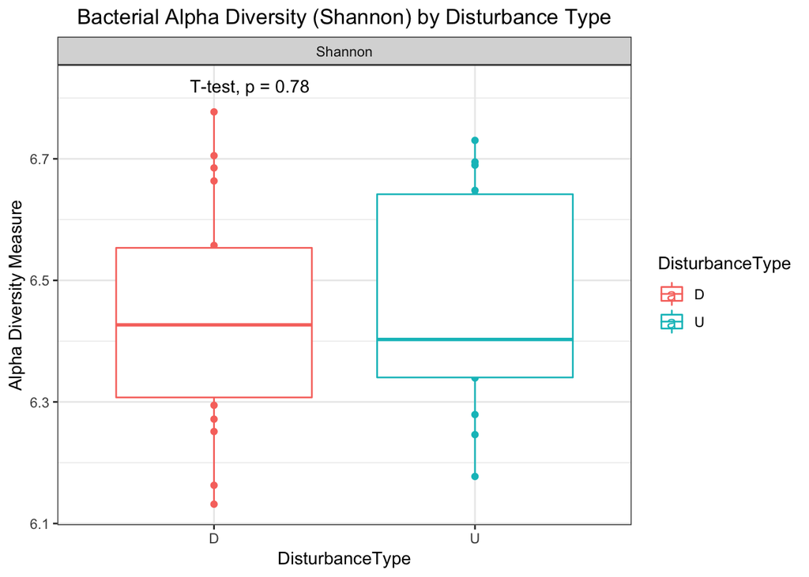

```r
physeq.prune.rarefy.plot.richness.disturbance = plot_richness(physeq.prune.rarefy, x="DisturbanceType", color=("DisturbanceType"),
                                                              measures=c("Shannon")) +
  geom_boxplot() + ggtitle("Bacterial Alpha Diversity (Shannon) by Disturbance Type") +
  stat_compare_means(method = "t.test", label.y = 6.82) + theme_bw() + theme(plot.title = element_text(hjust = 0.5))

physeq.prune.rarefy.plot.richness.disturbance
```

To double check t-test , p-value, follwing codes should provide p-value for the group that is being tested.

```r
alpha.diversity = estimate_richness(physeq.prune.rarefy, measures = c("Shannon"))
SAM = sample_data(physeq.prune.rarefy)
Disturbed = alpha.diversity[SAM[,'DisturbanceType'] == 'D',]
Undisturbed = alpha.diversity[SAM[,'DisturbanceType'] == 'U',]
t.test(Disturbed, Undisturbed)
```

```
##
##  Welch Two Sample t-test
##
## data:  Disturbed and Undisturbed
## t = -0.28501, df = 31.81, p-value = 0.7775
## alternative hypothesis: true difference in means is not equal to 0
## 95 percent confidence interval:
##  -0.1463257  0.1104113
## sample estimates:
## mean of x mean of y
##  6.443580  6.461537
```